# R Notebook

Summary

Presidential inauguration indicate the beginning of a new four-year term of the president. As one of the traditions, U.S. presidents always address their plans for next four years. This project will offer a broad introduction about word, sentences for presidential inauguration throughout the years, and analyze the differences between Democrat and Republican presidents.

# Part 1 Data Preparation

Step 0: check and install needed packages. Load the libraries and functions.

```r
packages.used=c("rvest", "tibble", "qdap",
                "sentimentr", "gplots", "dplyr",
                "tm", "syuzhet", "factoextra",
                "beeswarm", "scales", "RColorBrewer",
                "RANN", "tm", "topicmodels")
# check packages that need to be installed.
packages.needed=setdiff(packages.used,
                        intersect(installed.packages()[,1],
                                  packages.used))
# install additional packages
if(length(packages.needed)>0){
  install.packages(packages.needed, dependencies = TRUE)
}
#sudo ln -f -s $(/usr/libexec/java_home)/jre/lib/server/libjvm.dylib /usr/local/lib
# load packages
library("rvest")
library("tibble")
library("qdap")
library("sentimentr")
library("gplots")
library("dplyr")
library("tm")
library("syuzhet")
library("factoextra")
library("beeswarm")
library("scales")
library("RColorBrewer")
library("RANN")
library("tm")
library("topicmodels")
source("../lib/plotstacked.R")
source("../lib/speechFuncs.R")
```

This notebook was prepared with the following environmental settings.

```r
print(R.version)
```

```
               _
platform       x86_64-apple-darwin13.4.0
arch           x86_64
os             darwin13.4.0
system         x86_64, darwin13.4.0
status
major          3
minor          3.3
year           2017
month          03
day            06
svn rev        72310
language       R
version.string R version 3.3.3 (2017-03-06)
nickname       Another Canoe
```

Step 1: Data harvest: scrap speech URLs from http://www.presidency.ucsb.edu/.

```r
as.Date(inaug[,1], format="%B %e, %Y")
```

```
 [1] "1789-04-30" "1793-03-04" "1797-03-04" "1801-03-04" "1805-03-04" "1809-03-04" "1813-03-04" "1817-03-04"
 [9] "1821-03-04" "1825-03-04" "1829-03-04" "1833-03-04" "1837-03-04" "1841-03-04" "1845-03-04" "1849-03-05"
[17] "1853-03-04" "1857-03-04" "1861-03-04" "1865-03-04" "1869-03-04" "1873-03-04" "1877-03-05" "1881-03-04"
[25] "1885-03-04" "1889-03-04" "1893-03-04" "1897-03-04" "1901-03-04" "1905-03-04" "1909-03-04" "1913-03-04"
[33] "1917-03-04" "1921-03-04" "1925-03-04" "1929-03-04" "1933-03-04" "1937-01-20" "1941-01-20" "1945-01-20"
[41] "1949-01-20" "1953-01-20" "1957-01-21" "1961-01-20" "1965-01-20" "1969-01-20" "1973-01-20" "1977-01-20"
[49] "1981-01-20" "1985-01-21" "1989-01-20" "1993-01-20" "1997-01-20" "2001-01-20" "2005-01-20" "2009-01-20"
[57] "2013-01-21" "2017-01-20" NA
```

Step 2: Using speech metadata posted on http://www.presidency.ucsb.edu/, we prepared CSV data sets for the speeches we will scrap.

```r
inaug.list=read.csv("../data/inauglist.csv", stringsAsFactors = FALSE)
```

Step 3: scrap the texts of speeches from the speech URLs.

```r
speech.list=inaug.list
speech.url=inaug
speech.list$type=rep("inaug", nrow(inaug.list))
speech.list=cbind(speech.list, speech.url)
```

```r
# Loop over each row in speech.list
speech.list$fulltext=NA
for(i in seq(nrow(speech.list))) {
  text <- read_html(speech.list$urls[i]) %>% # load the page
    html_nodes(".displaytext") %>% # isloate the text
    html_text() # get the text
  speech.list$fulltext[i]=text
  # Create the file name
  filename <- paste0("../data/fulltext/",
                     speech.list$type[i],
                     speech.list$File[i], "-",
                     speech.list$Term[i], ".txt")
  sink(file = filename) %>% # open file to write
  cat(text)  # write the file
  sink() # close the file
}
```

# Part 2 Overview of sentence length distribution by different types of speeches.

In this part, we first genrate a sentence length distribution for all presidential inauguration. Then, we compare the sentence length distribution for Republican presidents and democrat presidents.

```r
sentence.list=NULL
for(i in 1:nrow(speech.list)){
  sentences=sent_detect(speech.list$fulltext[i],
                        endmarks = c("?", ".", "!", "|",";"))
  if(length(sentences)>0){
    emotions=get_nrc_sentiment(sentences)
    word.count=word_count(sentences)
    # colnames(emotions)=paste0("emo.", colnames(emotions))
    # in case the word counts are zeros?
    emotions=diag(1/(word.count+0.01))%*%as.matrix(emotions)
    sentence.list=rbind(sentence.list,
                        cbind(speech.list[i,-ncol(speech.list)],
                              sentences=as.character(sentences),
                              word.count,
                              emotions,
                              sent.id=1:length(sentences)
                              )
    )
  }
}
```

Some non-sentences exist in raw data due to erroneous extra end-of sentence marks.

```r
sentence.list=
  sentence.list%>%
  filter(!is.na(word.count))
```

Step 1: list out presidents names

Names list(all Predsidents)

```r
sel.comparison
```

```
 [1] "John Adams"             "Thomas Jefferson"       "James Madison"          "James Monroe"
 [5] "John Quincy Adams"      "Andrew Jackson"         "Martin van Buren"       "William Henry Harrison"
 [9] "James K. Polk"          "Zachary Taylor"         "Franklin Pierce"        "James Buchanan"
[13] "Abraham Lincoln"        "Ulysses S. Grant"       "Rutherford B. Hayes"    "James Garfield"
[17] "Grover Cleveland - I"   "Benjamin Harrison"      "Grover Cleveland - II"  "William McKinley"
[21] "Theodore Roosevelt"     "William Howard Taft"    "Woodrow Wilson"         "Warren G. Harding"
[25] "Calvin Coolidge"        "Herbert Hoover"         "Franklin D. Roosevelt"  "Harry S. Truman"
[29] "Dwight D. Eisenhower"   "John F. Kennedy"        "Lyndon B. Johnson"      "Richard Nixon"
[33] "Jimmy Carter"           "Ronald Reagan"          "George Bush"            "William J. Clinton"
[37] "George W. Bush"         "Barack Obama"           "Donald J. Trump"
```

Names list(Republican Predsidents)

```r
sel.comparison.republican
```

```
 [1] "Abraham Lincoln"      "Ulysses S. Grant"     "Rutherford B. Hayes"  "James Garfield"
 [5] "Benjamin Harrison"    "William McKinley"     "Theodore Roosevelt"   "William Howard Taft"
 [9] "Warren G. Harding"    "Calvin Coolidge"      "Herbert Hoover"       "Dwight D. Eisenhower"
[13] "Richard Nixon"        "Ronald Reagan"        "George Bush"          "George W. Bush"
[17] "Donald J. Trump"
```

```r
sel.comparison.democratic
```

```
 [1] "Andrew Jackson"        "Martin van Buren"      "James K. Polk"         "Franklin Pierce"
 [5] "James Buchanan"        "Grover Cleveland - I"  "Grover Cleveland - II" "Woodrow Wilson"
 [9] "Franklin D. Roosevelt" "Harry S. Truman"       "John F. Kennedy"       "Lyndon B. Johnson"
[13] "Jimmy Carter"          "William J. Clinton"    "Barack Obama"
```

Step 2: Name list cleaning and processing

```r
# remove space, speical symbols and eliminate duplicates
sel.comparison.republican=gsub(" ","",sel.comparison.republican)
sel.comparison.republican=gsub(".","",sel.comparison.republican,fixed = TRUE)
sel.comparison.republican=gsub("*(2)","",sel.comparison.republican,fixed = TRUE)
sel.comparison.republican=unique(gsub("*(3)","",sel.comparison.republican,fixed = TRUE))

sel.comparison.democratic=gsub(" ","",sel.comparison.democratic)
sel.comparison.democratic=gsub(".","",sel.comparison.democratic,fixed = TRUE)
sel.comparison.democratic=gsub("*(2)","",sel.comparison.democratic,fixed = TRUE)
sel.comparison.democratic=unique(gsub("*(3)","",sel.comparison.democratic,fixed = TRUE))

sel.comparison=gsub(" ","",sel.comparison)
sel.comparison=gsub(".","",sel.comparison,fixed = TRUE)
sel.comparison=gsub("*(2)","",sel.comparison,fixed = TRUE)
sel.comparison=unique(gsub("*(3)","",sel.comparison,fixed = TRUE))
```

Step 3: Sentence Length distribution

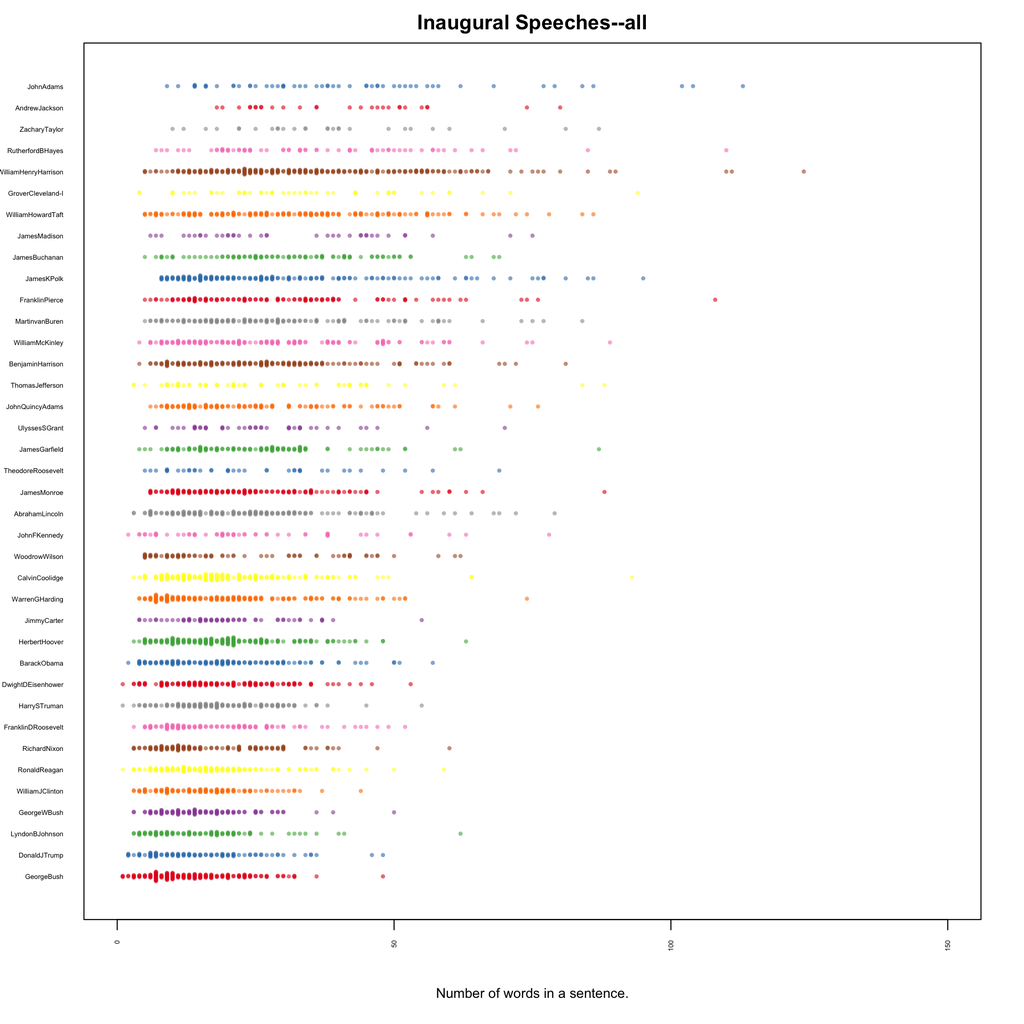

The figure above shows that the sentence lentgh of speeches for each president vary. Guess: The main reason may be caused my different speech styples for every president, different education background (i.e. law, arts vs science degree) or coming from two parties.

Let’s see the sentence length for Repubican presidents:

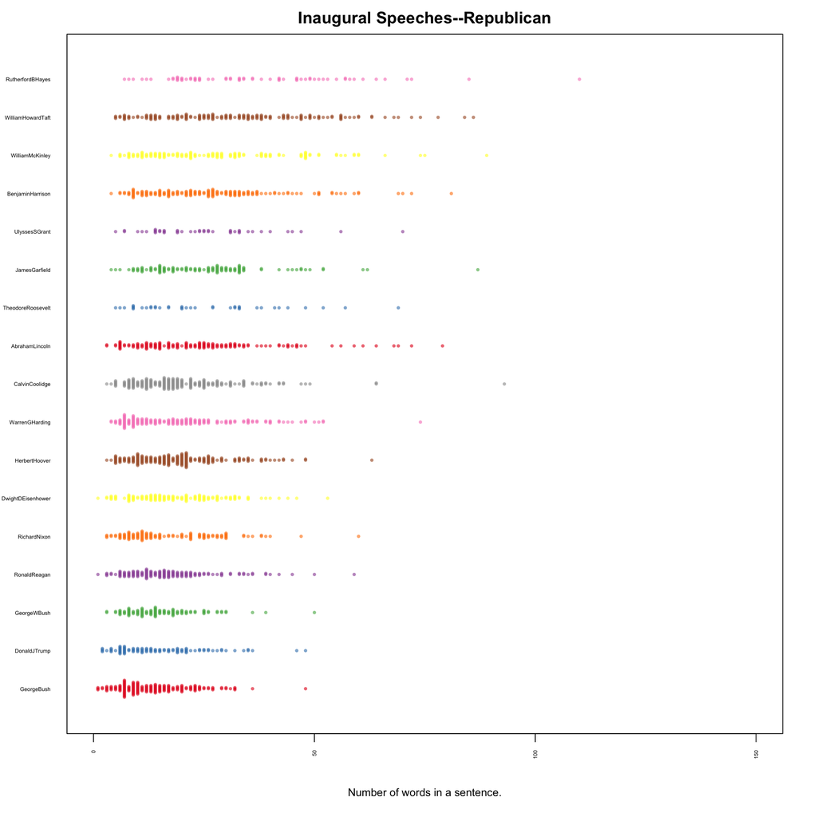

Here is the sentence length for Democratic presidents:

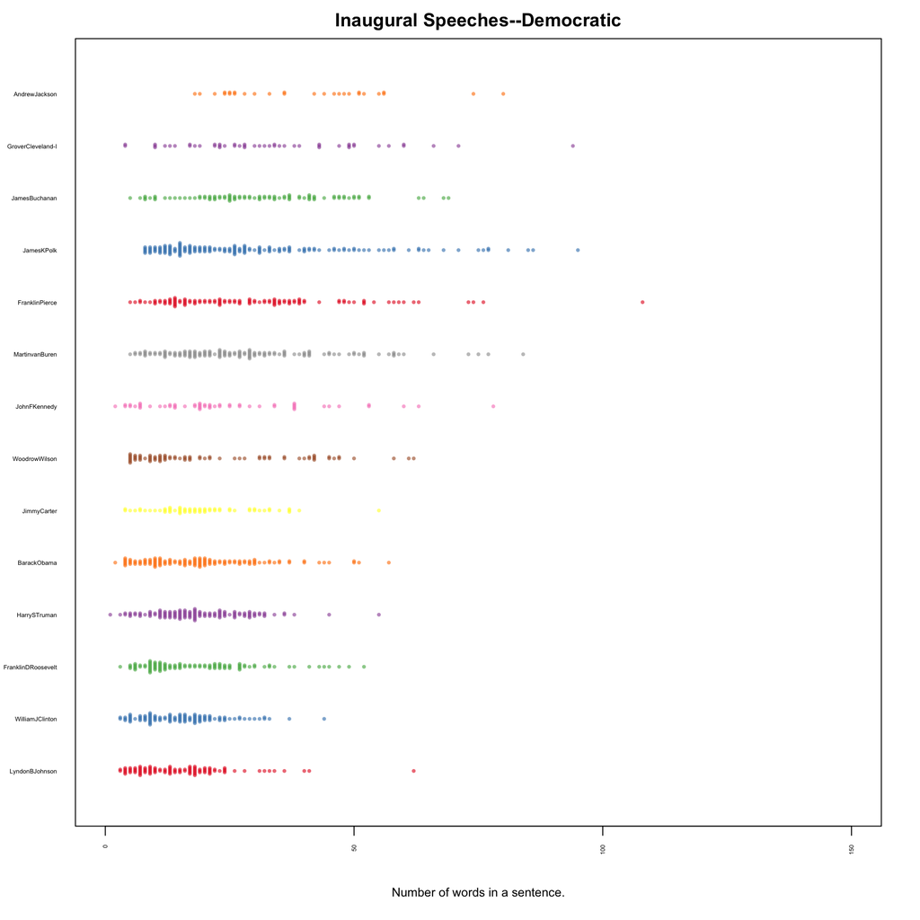

Most of the sentence length is within 0-50. For both parties, only one president has sentence length > 100. This indicate the sentence length difference is not caused by party difference. For the education background, thinking as President Obama (with JD degree ) vs Predsident Trump (with Bachelor degree in Economics), the figures do not show huge differences between their speeches. The conclusion is that the sentence speech difference might indicate personal speech style for every president.

# Part 3 sentiment analysis

In this part, I will do the sentiment analysis to see whether it has emotion difference betweeen two parties.

Step 1 Clustering of emotions Democrat

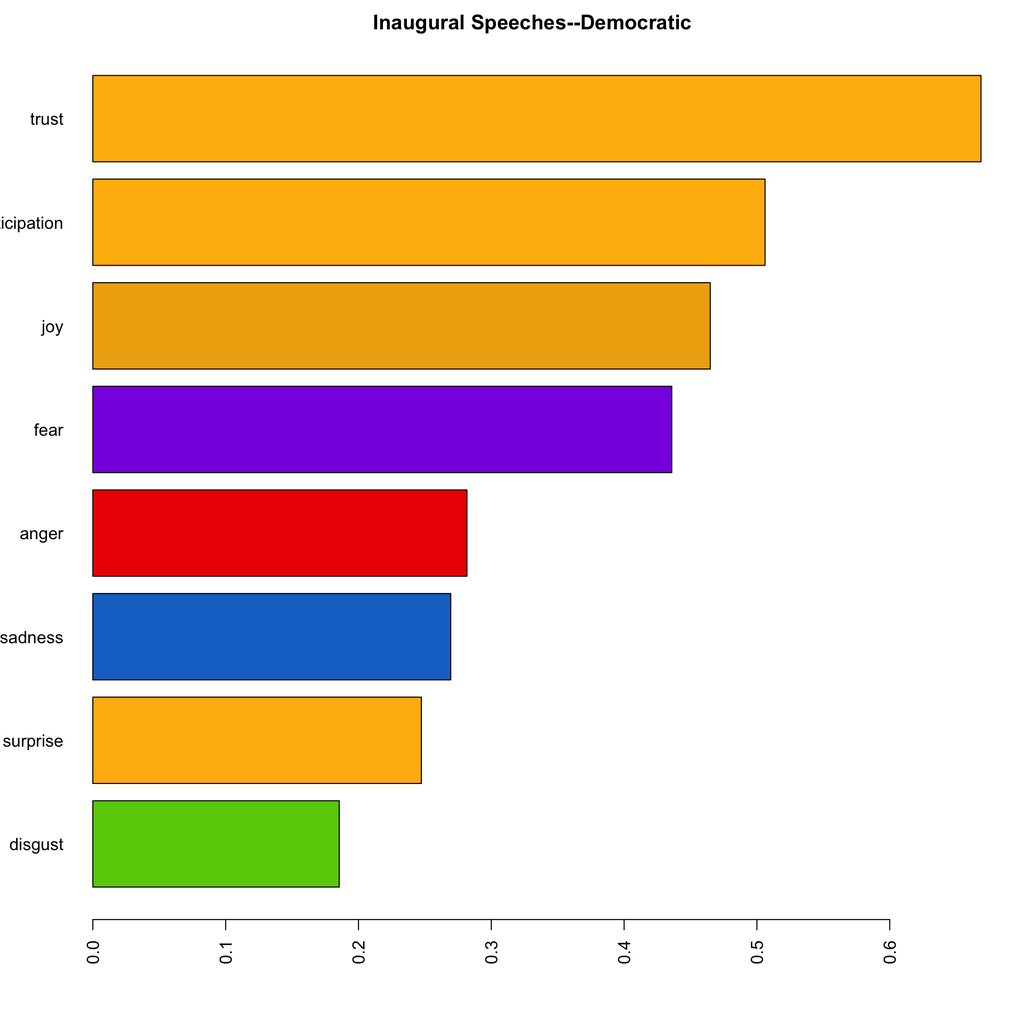

Republican

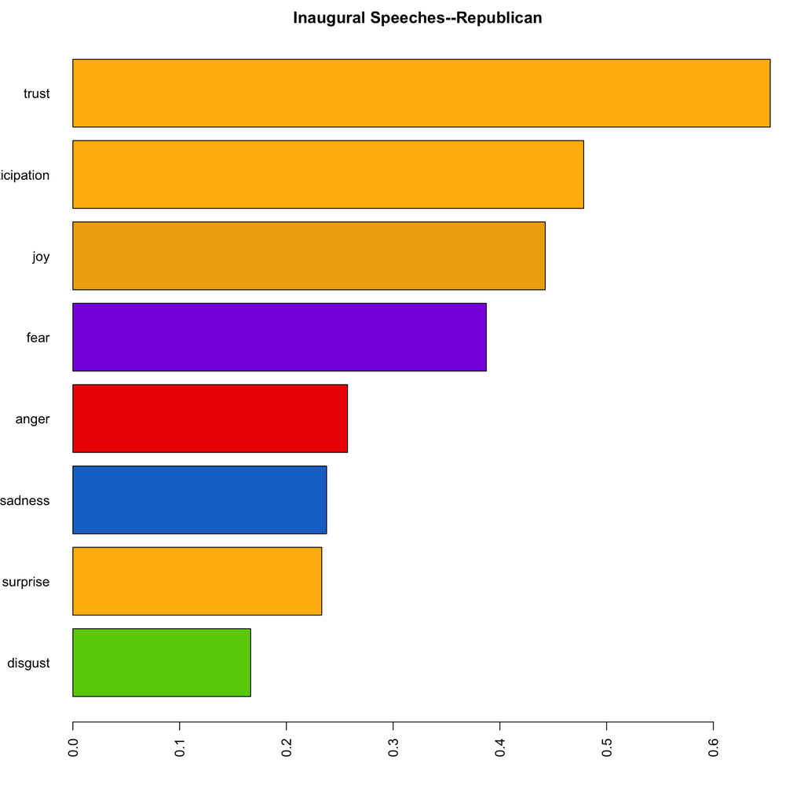

```r
emo.means.democratic
```

```
       anger anticipation      disgust         fear          joy      sadness     surprise        trust
   0.2816794    0.5061069    0.1854962    0.4358779    0.4648855    0.2694656    0.2473282    0.6687023
```

```r
emo.means.republican
```

```
       anger anticipation      disgust         fear          joy      sadness     surprise        trust
   0.2572993    0.4785584    0.1665146    0.3873175    0.4425182    0.2376825    0.2331204    0.6532847
```

Based on barcharts, we could see that both parties focus on trust and joy a lot. However, Presidents from Repulican party talked less with fear and anger emotion. One of the possible guess is due to facing economics recession or not. Only one Democrat President, President Obama, faces 2008 Finanical crisis. However, a lot of Republicans presidents faced economic recession while they gave the speeches.

Let’s dig into some fact about economic recession in U.S. Here are the list for recession year in U.S. December 1969 - Novemeber 1970 November 1973 -March 1975 July 1981 - Nov 1982 July 1990 - March 1991 March 2001 - November 2001 December 2007 - June 2009

All recessions above were preceded by an invertied term structure. Which president faced those economic recession? Republian: Richard Milhous Nixon, 1969-1974 Gerald Rudolph Ford, 1974-1977 Ronald Wilson Reagan, 1981-1989 George Herbert Walker Bush, 1989-1993 George Walker Bush, 2001-2009 Democrat: Barack Hussein Obama, 2009-2017

Next step, we will use clustering to see whether president facing economic recession have similar emotions during the speech.

Democrat

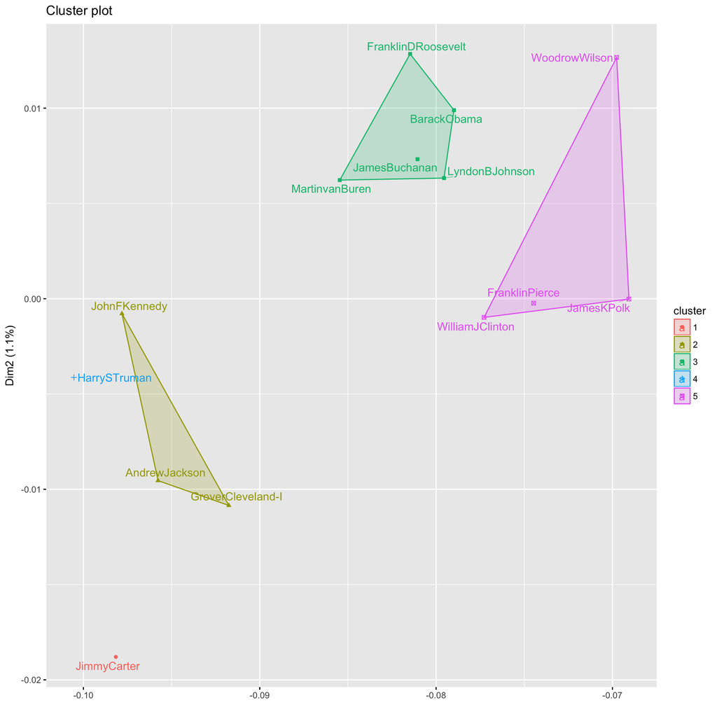

Republican

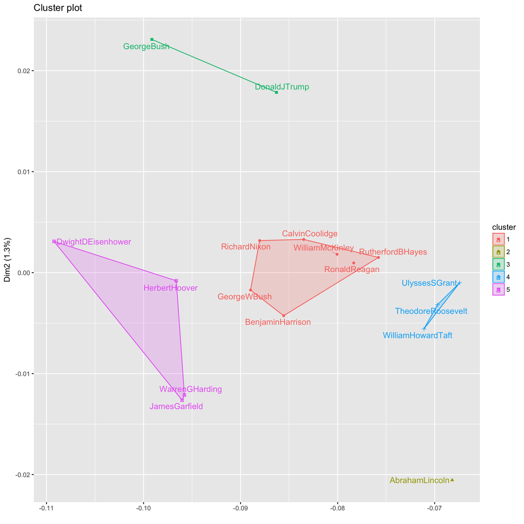

```r
presid.summary.republican
```

[output not shown]

# Part 4 Word Cloud Analysis

With sentiment analysis, we want to explore more about what presidents talked about in their speeches.

Step 0 - Install and load libraries

```r
packages.used=c("tm", "wordcloud", "RColorBrewer",
                "dplyr", "tydytext")

# check packages that need to be installed.
packages.needed=setdiff(packages.used,
                        intersect(installed.packages()[,1],
                                  packages.used))

# install additional packages
if(length(packages.needed)>0){
  install.packages(packages.needed, dependencies = TRUE,
                   repos='http://cran.us.r-project.org')
}

library(tm)
library(wordcloud)
library(RColorBrewer)
library(dplyr)
library(tidytext)
```

Step 1 - Read in the speeches

```r
# Republican
folder.path.republican="../data/inauguralsRep/"
speeches.republican=list.files(path = folder.path.republican, pattern = "*.txt")
prex.out.republican=substr(speeches.republican, 6, nchar(speeches.republican)-4)
ff.all.republican<-Corpus(DirSource(folder.path.republican))
```

```r
# Democrat
folder.path.democratic="../data/inauguralsDem/"
speeches.democratic=list.files(path = folder.path.democratic, pattern = "*.txt")
prex.out.democratic=substr(speeches.democratic, 6, nchar(speeches.democratic)-4)
ff.all.democratic<-Corpus(DirSource(folder.path.democratic))
```

Step 2 - Text processing

```r
# Republican
ff.all.republican<-tm_map(ff.all.republican, stripWhitespace)
ff.all.republican<-tm_map(ff.all.republican, content_transformer(tolower))
ff.all.republican<-tm_map(ff.all.republican, removeWords, stopwords("english"))
ff.all.republican<-tm_map(ff.all.republican, removeWords, character(0))
ff.all.republican<-tm_map(ff.all.republican, removePunctuation)
tdm.all.republican<-TermDocumentMatrix(ff.all.republican)

tdm.tidy.republican=tidy(tdm.all.republican)

tdm.overall.republican=summarise(group_by(tdm.tidy.republican, term), sum(count))
```

```r
# Democrat
ff.all.democratic<-tm_map(ff.all.democratic, stripWhitespace)
ff.all.democratic<-tm_map(ff.all.democratic, content_transformer(tolower))
ff.all.democratic<-tm_map(ff.all.democratic, removeWords, stopwords("english"))
ff.all.democratic<-tm_map(ff.all.democratic, removeWords, character(0))
ff.all.democratic<-tm_map(ff.all.democratic, removePunctuation)
tdm.all.democratic<-TermDocumentMatrix(ff.all.democratic)

tdm.tidy.democratic=tidy(tdm.all.democratic)

tdm.overall.democratic=summarise(group_by(tdm.tidy.democratic, term), sum(count))
```

Step 3 - Inspect an overall wordcloud

```r
# Republican
wordcloud(tdm.overall.republican$term, tdm.overall.republican$`sum(count)`,
          scale=c(3,0.5),
          max.words=300,
          min.freq=1,
          random.order=FALSE,
          rot.per=0.3,
          use.r.layout=T,
          random.color=FALSE,
          colors=brewer.pal(9,"Blues"))
```

[output not shown]

```r
# Democrat
wordcloud(tdm.overall.democratic$term, tdm.overall.democratic$`sum(count)`,
          scale=c(3,0.5),
          max.words=300,
          min.freq=1,
          random.order=FALSE,
          rot.per=0.3,
          use.r.layout=T,
          random.color=FALSE,
          colors=brewer.pal(9,"Blues"))
```

[output not shown]

# Part 4 Word Cloud Analysis w/ Rshiny for Individual Speech

Step 1 - Read in the speeches

```r
folder.path="../data/inaugurals/"
speeches=list.files(path = folder.path, pattern = "*.txt")
prex.out=substr(speeches, 6, nchar(speeches)-4)

ff.all<-Corpus(DirSource(folder.path))
```

Step 2 - Text processing

```r
ff.all<-tm_map(ff.all, stripWhitespace)
ff.all<-tm_map(ff.all, content_transformer(tolower))
ff.all<-tm_map(ff.all, removeWords, stopwords("english"))
ff.all<-tm_map(ff.all, removeWords, character(0))
ff.all<-tm_map(ff.all, removePunctuation)
tdm.all<-TermDocumentMatrix(ff.all)

tdm.tidy=tidy(tdm.all)

tdm.overall=summarise(group_by(tdm.tidy, term), sum(count))
```

Step 3 - compute TF-IDF weighted document-term matrices for individual speeches. As we would like to identify interesting words for each inaugural speech, we use [TF-IDF](https://en.wikipedia.org/wiki/Tf%E2%80%93idf) to weigh each term within each speech. It highlights terms that are more specific for a particular speech.

```r
dtm <- DocumentTermMatrix(ff.all,
                          control = list(weighting = function(x)
                                             weightTfIdf(x,
                                                         normalize =FALSE),
                                         stopwords = TRUE))
ff.dtm=tidy(dtm)
```

Step 4- Interactive visualize important words in individual speeches

```r
shinyApp(
    ui = fluidPage(
      fluidRow(style = "padding-bottom: 20px;",
        column(4, selectInput('speech1', 'Speech 1',
                              speeches,
                              selected=speeches[5])),
        column(4, selectInput('speech2', 'Speech 2', speeches,
                              selected=speeches[9])),
        column(4, sliderInput('nwords', 'Number of words', 3,
                               min = 20, max = 200, value=100, step = 20))
      ),
      fluidRow(
        plotOutput('wordclouds', height = "400px")
      )
    ),

    server = function(input, output, session) {

      # Combine the selected variables into a new data frame
      selectedData <- reactive({
        list(dtm.term1=ff.dtm$term[ff.dtm$document==as.character(input$speech1)],
             dtm.count1=ff.dtm$count[ff.dtm$document==as.character(input$speech1)],
             dtm.term2=ff.dtm$term[ff.dtm$document==as.character(input$speech2)],
             dtm.count2=ff.dtm$count[ff.dtm$document==as.character(input$speech2)])
      })

      output$wordclouds <- renderPlot(height = 400, {
        par(mfrow=c(1,2), mar = c(0, 0, 3, 0))
        wordcloud(selectedData()$dtm.term1,
                  selectedData()$dtm.count1,
              scale=c(4,0.5),
              max.words=input$nwords,
              min.freq=1,
              random.order=FALSE,
              rot.per=0,
              use.r.layout=FALSE,
              random.color=FALSE,
              colors=brewer.pal(10,"Blues"),
            main=input$speech1)
        wordcloud(selectedData()$dtm.term2,
                  selectedData()$dtm.count2,
              scale=c(4,0.5),
              max.words=input$nwords,
              min.freq=1,
              random.order=FALSE,
              rot.per=0,
              use.r.layout=FALSE,
              random.color=FALSE,
              colors=brewer.pal(10,"Blues"),
            main=input$speech2)
      })
    },

    options = list(height = 600)
)
```

# Part 5 Topic Modeling

In this part, we will analysis what topics presidents from two parties talked about.

For topic modeling, we prepare a corpus of sentence snipets as follows. For each speech, we start with sentences and prepare a snipet with a given sentence with the flanking sentences.

```r
#Republican
corpus.list.republican=sentence.list.sel.republican[2:(nrow(sentence.list.sel.republican)-1), ]
sentence.pre.republican=sentence.list.sel.republican$sentences[1:(nrow(sentence.list.sel.republican)-2)]
sentence.post.republican=sentence.list.sel.republican$sentences[3:(nrow(sentence.list.sel.republican)-1)]
corpus.list.republican$snipets=paste(sentence.pre.republican, corpus.list.republican$sentences, sentence.post.republican, sep=" ")
rm.rows.republican=(1:nrow(corpus.list.republican))[corpus.list.republican$sent.id==1]
rm.rows.republican=c(rm.rows.republican, rm.rows.republican-1)
corpus.list.republican=corpus.list.republican[-rm.rows.republican, ]
```

```r
# Democrat
corpus.list.democratic=sentence.list.sel.democratic[2:(nrow(sentence.list.sel.democratic)-1), ]
sentence.pre.democratic=sentence.list.sel.democratic$sentences[1:(nrow(sentence.list.sel.democratic)-2)]
sentence.post.democratic=sentence.list.sel.democratic$sentences[3:(nrow(sentence.list.sel.democratic)-1)]
corpus.list.democratic$snipets=paste(sentence.pre.democratic, corpus.list.democratic$sentences, sentence.post.democratic, sep=" ")
rm.rows.democratic=(1:nrow(corpus.list.democratic))[corpus.list.democratic$sent.id==1]
rm.rows.democratic=c(rm.rows.democratic, rm.rows.democratic-1)
corpus.list.democratic=corpus.list.democratic[-rm.rows.democratic, ]
```

Text mining

```r
#Republican
docs.republican <- Corpus(VectorSource(corpus.list.republican$snipets))
writeLines(as.character(docs.republican[[sample(1:nrow(corpus.list.republican), 1)]]))
```

```r
# Democrat
docs.democratic <- Corpus(VectorSource(corpus.list.democratic$snipets))
writeLines(as.character(docs.democratic[[sample(1:nrow(corpus.list.democratic), 1)]]))
```

Text basic processing Adapted from https://eight2late.wordpress.com/2015/09/29/a-gentle-introduction-to-topic-modeling-using-r/.

```r
#Republican
#remove potentially problematic symbols
docs.republican <-tm_map(docs.republican,content_transformer(tolower))
writeLines(as.character(docs.republican[[sample(1:nrow(corpus.list.republican), 1)]]))

#remove punctuation
docs.republican <- tm_map(docs.republican, removePunctuation)
writeLines(as.character(docs.republican[[sample(1:nrow(corpus.list.republican), 1)]]))

#Strip digits
docs.republican <- tm_map(docs.republican, removeNumbers)
writeLines(as.character(docs.republican[[sample(1:nrow(corpus.list.republican), 1)]]))

#remove stopwords
docs.republican <- tm_map(docs.republican, removeWords, stopwords("english"))
writeLines(as.character(docs.republican[[sample(1:nrow(corpus.list.republican), 1)]]))

#remove whitespace
docs.republican <- tm_map(docs.republican, stripWhitespace)
writeLines(as.character(docs.republican[[sample(1:nrow(corpus.list.republican), 1)]]))

#Stem document
docs.republican<- tm_map(docs.republican,stemDocument)
writeLines(as.character(docs.republican[[sample(1:nrow(corpus.list.republican), 1)]]))
```

```r
# Democrat
#remove potentially problematic symbols
docs.democratic <-tm_map(docs.democratic,content_transformer(tolower))
writeLines(as.character(docs.democratic[[sample(1:nrow(corpus.list.democratic), 1)]]))

#remove punctuation
docs.democratic <- tm_map(docs.democratic, removePunctuation)
writeLines(as.character(docs.democratic[[sample(1:nrow(corpus.list.democratic), 1)]]))

#Strip digits
docs.democratic <- tm_map(docs.democratic, removeNumbers)
writeLines(as.character(docs.democratic[[sample(1:nrow(corpus.list.democratic), 1)]]))

#remove stopwords
docs.democratic <- tm_map(docs.democratic, removeWords, stopwords("english"))
writeLines(as.character(docs.democratic[[sample(1:nrow(corpus.list.democratic), 1)]]))

#remove whitespace
docs.democratic <- tm_map(docs.democratic, stripWhitespace)
writeLines(as.character(docs.democratic[[sample(1:nrow(corpus.list.democratic), 1)]]))

#Stem document
docs.democratic<- tm_map(docs.democratic,stemDocument)
writeLines(as.character(docs.democratic[[sample(1:nrow(corpus.list.democratic), 1)]]))
```

Topic modeling

Gengerate document-term matrices.

```r
#Republican
dtm.republican <- DocumentTermMatrix(docs.republican)
#convert rownames to filenames#convert rownames to filenames
rownames(dtm.republican) <- paste(corpus.list.republican$type, corpus.list.republican$File,
                       corpus.list.republican$Term, corpus.list.republican$sent.id, sep="_")

rowTotals.republican <- apply(dtm.republican , 1, sum) #Find the sum of words in each Document

dtm.republican  <- dtm.republican[rowTotals.republican> 0, ]
corpus.list.republican=corpus.list.republican[rowTotals.republican>0, ]
```

```r
# Democrat
dtm.democratic <- DocumentTermMatrix(docs.democratic)
#convert rownames to filenames#convert rownames to filenames
rownames(dtm.democratic) <- paste(corpus.list.democratic$type, corpus.list.democratic$File,
                       corpus.list.democratic$Term, corpus.list.democratic$sent.id, sep="_")

rowTotals.democratic <- apply(dtm.democratic , 1, sum) #Find the sum of words in each Document

dtm.democratic  <- dtm.democratic[rowTotals.democratic> 0, ]
corpus.list.democratic=corpus.list.democratic[rowTotals.democratic>0, ]
```

Run LDA

```r
#Republican
#Set parameters for Gibbs sampling
burnin <- 4000
iter <- 2000
thin <- 500
seed <-list(2003,5,63,100001,765)
nstart <- 5
best <- TRUE

#Number of topics
k <- 15

#Run LDA using Gibbs sampling
ldaOut.republican <-LDA(dtm.republican, k, method="Gibbs", control=list(nstart=nstart,
                                                 seed = seed, best=best,
                                                 burnin = burnin, iter = iter,
                                                 thin=thin))
#write out results
#docs to topics
ldaOut.topics.republican <- as.matrix(topics(ldaOut.republican))
table(c(1:k, ldaOut.topics.republican))
write.csv(ldaOut.topics.republican,file=paste("../output/LDAGibbs",k,"DocsToTopicsRepublican.csv"))

#top 6 terms in each topic
ldaOut.terms.republican <- as.matrix(terms(ldaOut.republican,20))
write.csv(ldaOut.terms.republican,file=paste("../output/LDAGibbs",k,"TopicsToTermsRepublican.csv"))

#probabilities associated with each topic assignment
topicProbabilities.republican <- as.data.frame(ldaOut.republican@gamma)
write.csv(topicProbabilities.republican,file=paste("../output/LDAGibbs",k,"TopicProbabilitiesRepublican.csv"))
```

```r
# Democrat
#Set parameters for Gibbs sampling
burnin <- 4000
iter <- 2000
thin <- 500
seed <-list(2003,5,63,100001,765)
nstart <- 5
best <- TRUE

#Number of topics
k <- 15

#Run LDA using Gibbs sampling
ldaOut.democratic <-LDA(dtm.democratic, k, method="Gibbs", control=list(nstart=nstart,
                                                 seed = seed, best=best,
                                                 burnin = burnin, iter = iter,
                                                 thin=thin))
#write out results
#docs to topics
ldaOut.topics.democratic <- as.matrix(topics(ldaOut.democratic))
table(c(1:k, ldaOut.topics.democratic))
write.csv(ldaOut.topics.democratic,file=paste("../output/LDAGibbs",k,"DocsToTopicsDemocratic.csv"))

#top 6 terms in each topic
ldaOut.terms.democratic <- as.matrix(terms(ldaOut.democratic,20))
write.csv(ldaOut.terms.democratic,file=paste("../output/LDAGibbs",k,"TopicsToTermsDemocratic.csv"))

#probabilities associated with each topic assignment
topicProbabilities.democratic <- as.data.frame(ldaOut.democratic@gamma)
write.csv(topicProbabilities.democratic,file=paste("../output/LDAGibbs",k,"TopicProbabilitiesDemocratic.csv"))
```

```r
#Republican
terms.beta.republican=ldaOut.republican@beta
terms.beta.republican=scale(terms.beta.republican)
topics.terms.republican=NULL
for(i in 1:k){
  topics.terms.republican=rbind(topics.terms.republican, ldaOut.republican@terms[order(terms.beta.republican[i,], decreasing = TRUE)[1:7]])
}
topics.terms.republican
ldaOut.terms.republican
```

[output not shown]

```r
# Democrat
terms.beta.democratic=ldaOut.democratic@beta
terms.beta.democratic=scale(terms.beta.democratic)
topics.terms.democratic=NULL
for(i in 1:k){
  topics.terms.democratic=rbind(topics.terms.democratic, ldaOut.democratic@terms[order(terms.beta.democratic[i,], decreasing = TRUE)[1:7]])
}
topics.terms.democratic
ldaOut.terms.democratic
```

[output not shown]

# Conculsion

Based on the analysis above, we could get presidents from two parties have different emotions and topics emphasis on throughout the years. Republican presidents put more attention on economy and avoid fearness or other negative emotions during economy recession. Since several Democrat presidents countered war (i.e. world war) during their term, Democrat presidents mentioned more about foreign affairs, peace and war in the speeches. Overall, presidents from two parties talked about government, unity and belief, which are the foundation for U.S.

# Appendix:

supplement code in python: because running LDA and other topic modeling in R is time-consuming, I used nltk and scikit-learn package in python to do some data exploration (i.e. LDA and n-gram). Beside that, I also used package genism for Hierarchical Dirichlet process, an unsupervised topic modelling method to explore how many topics the speeches for each parties cover. Due to the consistency of results in same programming language, I do not put python part in the report but still include the python code under the folder as appendix.